# Unidad 1 - Ejercicio - Manipulación de datos en R

Nidia Hernández

###### nidiahernandez@conicet.gov.ar

En esta ejercitación vamos a:

- aprender operaciones básicas de manipulación de dataframes: leer, mostrar, ordenar, seleccionar columnas, filtrar filas, eliminar duplicados, etc.
- realizar gráficos básicos con `ggplot2`
- guardar los resultados

Vamos a usar archivos csv compartidos en el [campus](https://campusvirtual.uces.edu.ar/course/view.php?id=5875#section-5) que contienen las anotaciones semánticas de [*Relación de las cosas sucedidas en el Río de la Plata*](http://hdlab.space/Relacion-de-las-cosas-sucedidas/) de Pero Hernández, [*Relación de un viaje al Río de la Plata*](http://hdlab.space/Relacion-de-un-viaje/) de Acarette du Biscay y [*La Argentina Manuscrita*](http://hdlab.space/La-Argentina-Manuscrita/) de Ruy Díaz de Guzmán. Estos textos forman parte de la biblioteca digital de HDCAICYT LAB disponible en [hdlab.space/biblioteca-digital](http://hdlab.space/biblioteca-digital/).

## Paquetes básicos de manipulación de datos

Comenzamos con las líneas habituales:

```r
rm(list = ls())
setwd('/home/nombredeusuario/mi-directorio-de-trabajo/')

library(readr)
library(dplyr)
```

`readr` es un paquete que permite leer y escribir archivos. En el caso de los archivos tabulares, reconoce automáticamente el tipo de datos de cada columna (cadena de caracteres, entero, fecha, booleano, etc.). El paquete `dplyr` permite manipular tablas (seleccionar filas o columnas, filtrar, renombrar, combinar tablas, etc.).

Los paquetes `readr` y `dplyr` son parte del núcleo de `tidyverse` (del inglés *tidy*–prolijo– y *universe*) una colección de librerías concebidas para trabajar en conjunto de manera eficiente y coherente siguiendo una filosofía común. El concepto de *tidy data* fue propuesto por Hadley Wickham en un [artículo de 2014](https://doi.org/10.18637/jss.v059.i10) para el *Journal of Statistical Software*.

## Leer archivos y seleccionar datos

Usamos la función `read_csv` para leer un archivo csv que contiene información sobre entidades reconocidas en *Relación de las cosas sucedidas en el Río de la Plata* y guardamos el contenido en la variable `phernandez`. Usamos el comando `head(dataframe, cantidaddelineas)` para mostrar los valores de las primeras 20 líneas del archivo:

```r
phernandez <- read_csv('corpus-manipulacion-de-datos/PHernandez_RelCosas.csv')
head(phernandez, 20)
```

| UUID | FILE | QUOTE_TRANSCRIPTION | ANCHOR | TYPE | URI | VOCAB_LABEL | VOCAB_TEMPORAL_BOUNDS | LAT | LNG | PLACE_TYPE | VERIFICATION_STATUS | TAGS | COMMENTS |
| --- | --- | --- | --- | --- | --- | --- | --- | --- | --- | --- | --- | --- | --- |
| 21d20499-6a7b-42ef-977a-c89b427bfd81 | Memoria de Pero Hernandez SECRETARIO DEL ADELANTADO ALVAR NUÑEZ CABEZA DE VACA 28 de Enero de 1545.txt | Pero Hernandez | char-offset:12 | PERSON | NA | NA | NA | NA | NA | NA | NA | conquistador\|alvarista\|administrativo\|escribano | De origen andaluz. Secretario y escribano en el Paraguay, redactó esta obra dirigida al \ninfante Don Carlos, relatando la expedición de Alvar Núñez Cabeza de \nVaca, con datos etnohistóricos y geográ… |
| dd6df07c-c878-4ccb-8fe2-9a7c63821e27 | Memoria de Pero Hernandez SECRETARIO DEL ADELANTADO ALVAR NUÑEZ CABEZA DE VACA 28 de Enero de 1545.txt | ALVAR NUÑEZ CABEZA DE VACA | char-offset:53 | PERSON | NA | NA | NA | NA | NA | NA | NA | militar\|conquistador\|alvarista | Álvar Núñez Cabeza de Vaca (Jerez de la Frontera, 1488/1490 - Sevilla, 27 de mayo de 1559) fue un descubridor y conquistador español que exploró la costa sur de Norteamérica desde la actual Florida pa… |
| 73fa2f54-b607-4b4d-9def-0e5632f57996 | Memoria de Pero Hernandez SECRETARIO DEL ADELANTADO ALVAR NUÑEZ CABEZA DE VACA 28 de Enero de 1545.txt | S. C. C. M. | char-offset:102 | PERSON | NA | NA | NA | NA | NA | NA | NA | NA | Siglas de Sacra Católica Cesárea Majestad |
| 79fca4f1-23d1-40de-8864-e046a7fd9a1d | Memoria de Pero Hernandez SECRETARIO DEL ADELANTADO ALVAR NUÑEZ CABEZA DE VACA 28 de Enero de 1545.txt | V. M. | char-offset:137 | PERSON | NA | NA | NA | NA | NA | NA | NA | NA | Refiere al Rey Carlos I de España y V del Sacro Imperio Romano Germánico. |
| b816604a-7814-49f1-85b9-089475618d34 | Memoria de Pero Hernandez SECRETARIO DEL ADELANTADO ALVAR NUÑEZ CABEZA DE VACA 28 de Enero de 1545.txt | provincia del Rio de la Plata | char-offset:293 | PLACE | http://www.hgis-indias.net/dokuwiki/doku.php?id=gazetteer:9001006 | San Salvador | NA | -33.67232 | -58.35180 | Ciudad | VERIFIED | NA | Refiere a la Provincia del Río de la Plata, un espacio creado a partir de las capitulaciones que firmó el primer \nadelantado Pedro de Mendoza con Carlos I en 1534. La misma limitaba al \nnorte con lo… |
| 5d51a231-94cd-4e21-8b87-2e6fd2cc16cd | Memoria de Pero Hernandez SECRETARIO DEL ADELANTADO ALVAR NUÑEZ CABEZA DE VACA 28 de Enero de 1545.txt | Pedro de Mendoza | char-offset:506 | PERSON | NA | NA | NA | NA | NA | NA | NA | conquistador\|militar\|adelantado | Refiere a Pedro de Mendoza o Pedro de Mendoza y Luján (Granada, 1499-Océano Atlántico, 23 de junio de 1537), militar de familia noble, caballero de Alcántara desde 1524, almirante y conquistador españ… |
| b554eb2e-b7dc-4c84-99bb-09f20c98c0d1 | Memoria de Pero Hernandez SECRETARIO DEL ADELANTADO ALVAR NUÑEZ CABEZA DE VACA 28 de Enero de 1545.txt | Sebastián Gaboto | char-offset:709 | PERSON | NA | NA | NA | NA | NA | NA | NA | conquistador\|militar | o Caboto (1477-1557), piloto y explorador de las coronas de España e Inglaterra. El propósito inicial de su expedición de 1526 era repetir la circunnavegación de Magallanes, pero decidió alterar el ru… |
| 47e86103-663d-401f-a122-d9658a7ed48e | Memoria de Pero Hernandez SECRETARIO DEL ADELANTADO ALVAR NUÑEZ CABEZA DE VACA 28 de Enero de 1545.txt | Don Pedro | char-offset:844 | PERSON | NA | NA | NA | NA | NA | NA | NA | alvarista\|militar\|conquistador\|adelantado | Refiere a Pedro de Mendoza. |
| 696e9926-66d2-438e-8abb-0e0340d45777 | Memoria de Pero Hernandez SECRETARIO DEL ADELANTADO ALVAR NUÑEZ CABEZA DE VACA 28 de Enero de 1545.txt | Juan de Ayolas | char-offset:891 | PERSON | NA | NA | NA | NA | NA | NA | NA | militar\|conquistador\|iralista | Refiere a Juan de Ayolas (Briviesca de la Bureba, Corona de Castilla, 1493 o ¿ca. 1510? – Candelaria del Chaco Boreal, gobernación del Río de la Plata y del Paraguay, 1538) era un explorador español q… |
| 1c2401ec-e489-4c85-9ade-b29de5b54164 | Memoria de Pero Hernandez SECRETARIO DEL ADELANTADO ALVAR NUÑEZ CABEZA DE VACA 28 de Enero de 1545.txt | Juan de Salazar | char-offset:1087 | PERSON | NA | NA | NA | NA | NA | NA | NA | conquistador\|capitán\|regidor\|tesorero\|iralista | Juan de Salazar y Espinoza (España, 1508 - Asunción, 1560), figura \npolítica importante en la colonización del Río de la Plata. Capitán de \nPedro de Mendoza a quien el Adelantado le encargó la misió… |

[output cut: 10 more lines]

`head()` nos permite ver el encabezado de la tabla y los primeros registros. En la salida de `head()`, vemos que esta tabla contiene muchísima información. Para este ejercicio, vamos a seleccionar sólo las columnas que indican el nombre de las entidades reconocidas (`QUOTE_TRANSCRIPTION`), el tipo de entidad (`TYPE`), las etiquetas asociadas a cada entidad (`TAGS`) y los comentarios (`COMMENTS`). Para eso, vamos a pasarle los nombres de las columnas que queremos seleccionar a la función `select()`. `select()` también nos permite renombrar columnas escribiendo `nuevo nombre = nombre actual`.

El flujo de los datos es el siguiente: el símbolo `%>%` (conocido como “pipe”) envía el contenido de la variable `phernandez` a la función `select()`. `select()` selecciona las columnas indicadas entre paréntesis y el resultado de esta selección es enviado a la función `arrange()` que ordena los resultados alfabéticamente siguiendo como prioridad el orden de las columnas indicadas entre paréntesis. El resultado de esta operación es asignado a la variable `phernandez_seleccion`. Como habrás notado, en R se estila escribir una operación por línea.

```r
phernandez_seleccion <-
  phernandez %>%
  select(ENTIDAD = QUOTE_TRANSCRIPTION, TYPE, TAGS, COMMENTS) %>%
  arrange(ENTIDAD, TYPE, TAGS)

phernandez_seleccion
```

| ENTIDAD | TYPE | TAGS | COMMENTS |
| --- | --- | --- | --- |
| Abacote | PERSON | indio | Cacique de la comunidad de Agaces |
| Abacote | PERSON | indio | Cacique de la comunidad de Agaces |
| Agaces | PERSON | aliado\|indio\|mataco\|guaycurú\|enemigo | Sociedad nativa que habitaba en el curso inferior del río Paraguay. Pertenecían al tronco lingüístico mataco-guaycurú, eran muy hábiles canoeros y pescadores. Solían tener conflictos con los guaraníes… |
| Agaces | PERSON | aliado\|indio\|mataco\|guaycurú\|enemigo | Sociedad nativa que habitaba en el curso inferior del río Paraguay. Pertenecían al tronco lingüístico mataco-guaycurú, eran muy hábiles canoeros y pescadores. Solían tener conflictos con los guaraníes… |
| Agaces | PERSON | indio\|mataco\|guaycurú\|enemigo\|aliado | Sociedad nativa que habitaba en el curso inferior del río Paraguay. Pertenecían al tronco lingüístico mataco-guaycurú, eran muy hábiles canoeros y pescadores. Solían tener conflictos con los guaraníes… |
| Aguilera | PERSON | conquistador\|regidor\|administrativo\|contador | Refiere a Pedro de Aguilera, contador real, regidor y encomendero. |
| Agustin de Madrid | PERSON | conquistador | NA |
| Albar Nuñez Cabesa de Vaca | PERSON | conquistador\|adelantado\|gobernador\|militar\|alvarista | Refiere a Álvar Núñez Cabeza de Vaca (Jerez de la Frontera, 1488/90-Sevilla, 27/05/1559), descubridor y conquistador que exploró la costa sur de América del norte, desde la actual Florida hasta el Gol… |
| Albár Nuñez Cabeza de Vaca | PERSON | conquistador\|militar\|adelantado\|alvarista\|gobernador | Refiere a Álvar Núñez Cabeza de Vaca (Jerez de la Frontera, 1488/90-Sevilla, 27/05/1559), descubridor y conquistador que exploró la costa sur de América del norte, desde la actual Florida hasta el Gol… |
| Albár Nuñez Cabeza de Vaca | PERSON | conquistador\|militar\|adelantado\|alvarista\|gobernador | Refiere a Álvar Núñez Cabeza de Vaca (Jerez de la Frontera, 1488/90-Sevilla, 27/05/1559), descubridor y conquistador que exploró la costa sur de América del norte, desde la actual Florida hasta el Gol… |

[output cut: 493 more lines]

En el chunk anterior podemos observar otra particularidad de R: basta con invocar una variable y ejecutar la porción de código correspondiente para poder ver el contenido de la variable en la consola. Así, podemos ver que la tabla `phernandez_seleccion` contiene muchas líneas duplicadas (pues se diferenciaban con valores de las columnas que ya no están). Para eliminar los registros duplicados, podemos usar la función `distinct`:

```r
nrow(phernandez)
```

```
## [1] 503
```

```r
phernandez_seleccion <- distinct(phernandez_seleccion)

nrow(phernandez_seleccion)
```

```
## [1] 230
```

En el código precedente usamos `nrow()`, una función que devuelve el número de filas de un dataframe. Como podemos observar comparando la salida de `nrow()` antes y después de aplicar `distinct()`, el tamaño del dataframe se redujo a menos de la mitad.

## Agrupar por valores, filtrar por valor y eliminar columnas

A continuación, vamos a inspeccionar cuántas entidades hay para cada tipo. En otras palabras, queremos saber cuántos registros hay para cada uno de los diferentes valores de la columna `TYPE`. Para eso, le indicamos a la función `group_by()` que se base en la columna `TYPE` y redirigimos el resultado a `summarise()` y `n()` que producen el conteo.

```r
phernandez_seleccion %>%
  group_by(TYPE) %>%
  summarise(nro_entidades = n())
```

| TYPE | nro_entidades |
| --- | --- |
| EVENT | 1 |
| PERSON | 200 |
| PLACE | 27 |
| NA | 2 |

En nuestro dataframe predominan las entidades referidas a personas. Vamos a filtrar el dataset para conservar sólo las entidades de tipo ‘PERSON’ usando `filter()`. La columna `TYPE` ya no aporta información en el resultado (todas las líneas van a tener valor ‘PERSON’), por lo que es mejor eliminarla. ¿Cómo borrar una columna de un dataframe? Muy sencillo, usamos `select()` con el nombre de la columna que queremos eliminar precedido de un signo `-`.

Guardamos en una nueva variable, `personajes`, el dataframe resultante de estas operaciones.

```r
personajes <-
  phernandez_seleccion %>%
  filter(TYPE == 'PERSON') %>%
  select(-TYPE)

personajes
```

| ENTIDAD | TAGS | COMMENTS |
| --- | --- | --- |
| Abacote | indio | Cacique de la comunidad de Agaces |
| Agaces | aliado\|indio\|mataco\|guaycurú\|enemigo | Sociedad nativa que habitaba en el curso inferior del río Paraguay. Pertenecían al tronco lingüístico mataco-guaycurú, eran muy hábiles canoeros y pescadores. Solían tener conflictos con los guaraníes… |
| Agaces | indio\|mataco\|guaycurú\|enemigo\|aliado | Sociedad nativa que habitaba en el curso inferior del río Paraguay. Pertenecían al tronco lingüístico mataco-guaycurú, eran muy hábiles canoeros y pescadores. Solían tener conflictos con los guaraníes… |
| Aguilera | conquistador\|regidor\|administrativo\|contador | Refiere a Pedro de Aguilera, contador real, regidor y encomendero. |
| Agustin de Madrid | conquistador | NA |
| Albar Nuñez Cabesa de Vaca | conquistador\|adelantado\|gobernador\|militar\|alvarista | Refiere a Álvar Núñez Cabeza de Vaca (Jerez de la Frontera, 1488/90-Sevilla, 27/05/1559), descubridor y conquistador que exploró la costa sur de América del norte, desde la actual Florida hasta el Gol… |
| Albár Nuñez Cabeza de Vaca | conquistador\|militar\|adelantado\|alvarista\|gobernador | Refiere a Álvar Núñez Cabeza de Vaca (Jerez de la Frontera, 1488/90-Sevilla, 27/05/1559), descubridor y conquistador que exploró la costa sur de América del norte, desde la actual Florida hasta el Gol… |
| Alonso | conquistador\|religioso\|iralista\|franciscano | Fray Alonso Lebrón, natural de Canarias, de la orden franciscana. Llega a\n América en la expedición de Alonso Cabrera en 1538 con fray Bernardo de\n Armenta, a quien acompañó en todas sus misiones en… |
| Alonso Cabrera | conquistador\|militar\|iralista | Alonso de Cabrera (España, s.XVI–1556). Veedor de la expedición que acudió en 1539 al Río de la Plata, para socorrer a los hombres de Mendoza. Litigó con Francisco Ruiz Galán y apoyó a Martínez Irala … |
| Alonso de Angulo | conquistador\|militar\|iralista\|alcalde | Refiere a Alonso de Angulo, natural de Córdoba, alcalde ordinario de la ciudad de Asunción. |

[output cut: 190 more lines]

Podemos observar que el dataframe ‘personajes’ tiene 200 registros. Esto coincide con el resultado del conteo realizado más arriba con `group_by()` y `summarise()`.

## Filtrar valores vacíos, extraer información y agregar columnas

Si observamos los valores de la columna `TAGS`, encontraremos que las entidades de nuestro dataset han sido categorizadas siguiendo un vocabulario controlado. También encontraremos que en algunos casos no han recibido ninguna categoría (cf. ‘Estevan de Vallejos’), en ese caso, el valor de `TAGS` es `NA`, es decir *not available* (no disponible).

Supongamos que nos interesa identificar personajes según su origen (pueblos originarios/invasores europeos) y según la facción (partidarios de Álvar Núñez y partidarios de Domingo de Irala) basándonos en la información de la columna `TAGS`. Vamos a crear una nueva variable `personajes_categ` en la que vamos a registrar esa información.

Primero eliminamos los personajes para los que no hay información (valor `NA` en `TAGS`) usando la función `drop_na()` de la librería `tidyr`. Luego, agregamos dos columnas nuevas `ORIGEN` y `FACCION`. En `ORIGEN` registraremos el valor ‘indio’ o ‘conquistador’ según el texto que encontremos para cada personaje en `TAGS`. En `FACCION` registraremos el valor ‘iralista’ o ‘alvarista’ de acuerdo a la información asignada a cada personaje en `TAGS`. Para esto, usamos una función de `stringr`, una librería de manipulación de cadenas de caracteres (o *strings*), llamada `str_extract()`. `str_extract()` permite extraer pequeños strings de strings más extensos. Tanto `stringr` como `tidyr` son parte de `tidyverse`. De ahora en adelante, en lugar de llamar a cada librería por separado, haremos `library(tidyverse)`.

Finalmente, volvemos a aplicar `distinct()` al resultado para eliminar filas duplicadas.

```r
library(stringr)
library(tidyr)

personajes_categ <-
  personajes %>%
  drop_na(TAGS) %>%
  mutate(
    ORIGEN = str_extract(TAGS, "indio|conquistador"),
    FACCION = str_extract(TAGS, "iralista|alvarista")
  ) %>%
  select(ENTIDAD, ORIGEN, FACCION) %>%
  distinct()

personajes_categ
```

| ENTIDAD | ORIGEN | FACCION |
| --- | --- | --- |
| Abacote | indio | NA |
| Agaces | indio | NA |
| Aguilera | conquistador | NA |
| Agustin de Madrid | conquistador | NA |
| Albar Nuñez Cabesa de Vaca | conquistador | alvarista |
| Albár Nuñez Cabeza de Vaca | conquistador | alvarista |
| Alonso | conquistador | iralista |
| Alonso Cabrera | conquistador | iralista |
| Alonso de Angulo | conquistador | iralista |
| Alonso de Valenzuela | conquistador | iralista |

[output cut: 151 more lines]

Con esta tabla de categorizacion de los personajes, podemos hacer un conte básico de orígenes y bandos. Recurrimos nuevamente a `group_by` y `summarise`.

```r
personajes_categ %>%
  group_by(ORIGEN, FACCION) %>%
  summarise(nro_entidades = n())
```

| ORIGEN | FACCION | nro_entidades |
| --- | --- | --- |
| conquistador | alvarista | 32 |
| conquistador | iralista | 59 |
| conquistador | NA | 48 |
| indio | NA | 22 |

## Generar gráficos

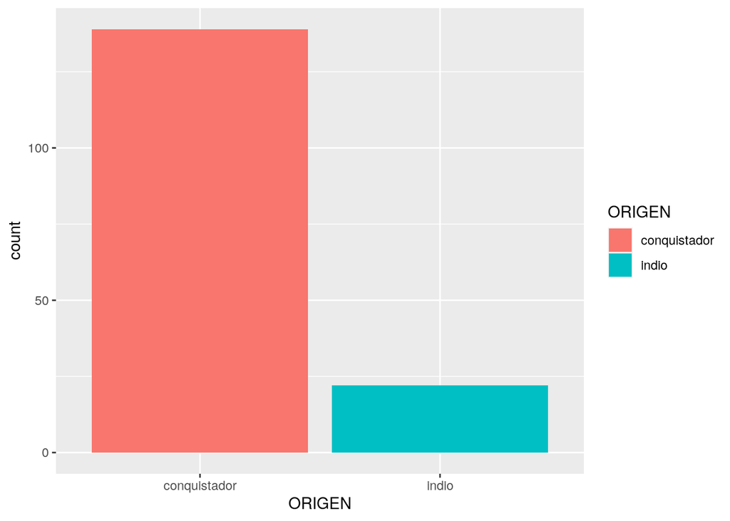

```r
library(ggplot2)

personajes_categ %>%
  ggplot() +
  aes(x = ORIGEN, fill = ORIGEN) +
  geom_bar()
```

Podemos guardar la última figura al disco con un nombre de archivo a elección.

```r
ggsave("conteo_personajes_categ.png")
```

## Unir dataframes

Vamos a extender el primer dataset con el que trabajamos, las entidades de la relación de Pero Hernández, con los datos de un segundo texto, *Relación de un viaje al Río de la Plata* de Acarette du Biscay.

```r
dubiscay <- read_csv("corpus-manipulacion-de-datos/DuBiscay_RelDeUnViaje.csv")
dubiscay
```

| UUID | FILE | QUOTE_TRANSCRIPTION | ANCHOR | TYPE | URI | VOCAB_LABEL | VOCAB_TEMPORAL_BOUNDS | LAT | LNG | PLACE_TYPE | VERIFICATION_STATUS | TAGS | COMMENTS |
| --- | --- | --- | --- | --- | --- | --- | --- | --- | --- | --- | --- | --- | --- |
| 9a43b4fb-fce4-4d51-9e48-9754251b2568 | Relación de un viaje al Río de la Plata Buscay.txt | Río de la Plata | char-offset:25 | PLACE | http://www.hgis-indias.net/dokuwiki/doku.php?id=gazetteer:9001006 | San Salvador | NA | -33.6723210 | -58.351799 | Ciudad | VERIFIED | NA | Refiere a la Provincia del Río de la Plata, un espacio creado a partir \nde las capitulaciones que firmó el primer adelantado Pedro de Mendoza \ncon Carlos I en 1534.La misma limitaba al norte con los… |
| 61e7cd4c-eef8-437a-b98a-d8a230c76828 | Relación de un viaje al Río de la Plata Buscay.txt | Perú | char-offset:65 | PLACE | http://www.hgis-indias.net/dokuwiki/doku.php?id=gazetteer:6000001 | Lima | NA | -12.0466526 | -77.029981 | Ciudad | VERIFIED | NA | Refiere al virreinato de Perú, creado en 1542, inicialmente incluía toda América del Sur bajo control español a excepción de las costas de lo que hoy es Venezuela. Más tarde perdió jurisdicción, con l… |
| 4e6e7acd-2c79-4557-8a01-733ddcf80801 | Relación de un viaje al Río de la Plata Buscay.txt | indios | char-offset:115 | PERSON | NA | NA | NA | NA | NA | NA | NA | NA | Refiere a pueblos originarios de América. |
| ee3856aa-7e59-4ed5-8140-11fa60753364 | Relación de un viaje al Río de la Plata Buscay.txt | América | char-offset:208 | PLACE | http://sws.geonames.org/6255150 | South America | NA | -15.1712061 | -60.789429 | NA | VERIFIED | NA | Si bien no se especifica a qué zona de América se hace referencia, y aunque los términos Sudamérica o América del Sur no pertenecen a esta época, por las regiones y ciudades que Acarete menciona, pode… |
| d17f7eb2-4938-46d2-b166-f125bf261e2d | Relación de un viaje al Río de la Plata Buscay.txt | Acarete du Biscay | char-offset:217 | PERSON | NA | NA | NA | NA | NA | NA | NA | capitán | Viajero francés, posiblemente de origen vasco. En diciembre de 1657 se embarcó en Cádiz, España, hacia la región del Río de la Plata en Sudamérica, haciéndose pasar por el sobrino de un caballero espa… |
| 7c358b07-fec8-42ae-8b66-3e91f8fd7e4d | Relación de un viaje al Río de la Plata Buscay.txt | España | char-offset:747 | PLACE | http://sws.geonames.org/2510769 | Spain | NA | 40.2282294 | -3.639067 | NA | VERIFIED | NA | NA |
| 82eea8a7-5540-4848-bf70-e1d13c093509 | Relación de un viaje al Río de la Plata Buscay.txt | Cádiz | char-offset:836 | PLACE | http://sws.geonames.org/2520600 | Cadiz | NA | 36.5297800 | -6.294650 | NA | VERIFIED | NA | NA |
| 4fd8b22b-0ac5-4c47-bf21-b4b32b0f17fb | Relación de un viaje al Río de la Plata Buscay.txt | Indias Occidentales | char-offset:875 | PLACE | NA | NA | NA | NA | NA | NA | NOT_IDENTIFIABLE | NA | Las Indias Occidentales forma de referirse al continente americano durante la época colonial. |
| fa8a1671-5207-469b-8b41-abe4f5b73d57 | Relación de un viaje al Río de la Plata Buscay.txt | Oliverio Cromwell | char-offset:1334 | PERSON | NA | NA | NA | NA | NA | NA | NA | NA | Refiere a Oliver\nCromwell (Huntingdon, Inglaterra, 25/04/1599-Londres,\n03/09/1658), líder político\ny militar\ninglés. Convirtió a Inglaterra en una república\ndenominada Mancomunidad de Inglaterra … |
| b1e4e401-36a7-4d81-9865-60d34fb3f1cd | Relación de un viaje al Río de la Plata Buscay.txt | Inglaterra | char-offset:1393 | PLACE | http://sws.geonames.org/2635167 | United Kingdom | NA | 54.1253951 | -2.859750 | NA | VERIFIED | NA | NA |

[output cut: 579 more lines]

Repetimos los tratamientos que realizamos anteriormente al dataframe `phernandez_seleccion`:

```r
dubiscay_seleccion <-
  dubiscay %>%
  rename(ENTIDAD = QUOTE_TRANSCRIPTION) %>%
  drop_na(TYPE) %>%
  select(ENTIDAD, TYPE, TAGS, COMMENTS) %>%
  distinct()

dubiscay_seleccion
```

| ENTIDAD | TYPE | TAGS | COMMENTS |
| --- | --- | --- | --- |
| Río de la Plata | PLACE | NA | Refiere a la Provincia del Río de la Plata, un espacio creado a partir \nde las capitulaciones que firmó el primer adelantado Pedro de Mendoza \ncon Carlos I en 1534.La misma limitaba al norte con los… |
| Perú | PLACE | NA | Refiere al virreinato de Perú, creado en 1542, inicialmente incluía toda América del Sur bajo control español a excepción de las costas de lo que hoy es Venezuela. Más tarde perdió jurisdicción, con l… |
| indios | PERSON | NA | Refiere a pueblos originarios de América. |
| América | PLACE | NA | Si bien no se especifica a qué zona de América se hace referencia, y aunque los términos Sudamérica o América del Sur no pertenecen a esta época, por las regiones y ciudades que Acarete menciona, pode… |
| Acarete du Biscay | PERSON | capitán | Viajero francés, posiblemente de origen vasco. En diciembre de 1657 se embarcó en Cádiz, España, hacia la región del Río de la Plata en Sudamérica, haciéndose pasar por el sobrino de un caballero espa… |
| España | PLACE | NA | NA |
| Cádiz | PLACE | NA | NA |
| Indias Occidentales | PLACE | NA | Las Indias Occidentales forma de referirse al continente americano durante la época colonial. |
| Oliverio Cromwell | PERSON | NA | Refiere a Oliver\nCromwell (Huntingdon, Inglaterra, 25/04/1599-Londres,\n03/09/1658), líder político\ny militar\ninglés. Convirtió a Inglaterra en una república\ndenominada Mancomunidad de Inglaterra … |
| Inglaterra | PLACE | NA | NA |

[output cut: 223 more lines]

Aquí, en lugar de renombrar la columna de entidades dentro del `select()` como hicimos anteriormente, lo hicimos en una línea diferente y usando la función `rename()`.

Una vez armonizadas las estructuras de ambos dataframes, podemos unirlos para conservar las entidades de ambos textos en una sola variable que llamaremos `corpus_pelagios`. Pero antes, vamos a agregar una nueva columna llamada `FUENTE` con la información del documento fuente de cada entidad. Luego concatenamos los dataframes con `bind_rows()`.

```r
dubiscay_seleccion <-
  dubiscay_seleccion %>%
  mutate(FUENTE = "Du Biscay")

phernandez_seleccion <-
  phernandez_seleccion %>%
  mutate(FUENTE = "Pero Hernandez")

corpus_pelagios <- bind_rows(
  phernandez_seleccion,
  dubiscay_seleccion
)

corpus_pelagios
```

| ENTIDAD | TYPE | TAGS | COMMENTS | FUENTE |
| --- | --- | --- | --- | --- |
| Abacote | PERSON | indio | Cacique de la comunidad de Agaces | Pero Hernandez |
| Agaces | PERSON | aliado\|indio\|mataco\|guaycurú\|enemigo | Sociedad nativa que habitaba en el curso inferior del río Paraguay. Pertenecían al tronco lingüístico mataco-guaycurú, eran muy hábiles canoeros y pescadores. Solían tener conflictos con los guaraníes… | Pero Hernandez |
| Agaces | PERSON | indio\|mataco\|guaycurú\|enemigo\|aliado | Sociedad nativa que habitaba en el curso inferior del río Paraguay. Pertenecían al tronco lingüístico mataco-guaycurú, eran muy hábiles canoeros y pescadores. Solían tener conflictos con los guaraníes… | Pero Hernandez |
| Aguilera | PERSON | conquistador\|regidor\|administrativo\|contador | Refiere a Pedro de Aguilera, contador real, regidor y encomendero. | Pero Hernandez |
| Agustin de Madrid | PERSON | conquistador | NA | Pero Hernandez |
| Albar Nuñez Cabesa de Vaca | PERSON | conquistador\|adelantado\|gobernador\|militar\|alvarista | Refiere a Álvar Núñez Cabeza de Vaca (Jerez de la Frontera, 1488/90-Sevilla, 27/05/1559), descubridor y conquistador que exploró la costa sur de América del norte, desde la actual Florida hasta el Gol… | Pero Hernandez |
| Albár Nuñez Cabeza de Vaca | PERSON | conquistador\|militar\|adelantado\|alvarista\|gobernador | Refiere a Álvar Núñez Cabeza de Vaca (Jerez de la Frontera, 1488/90-Sevilla, 27/05/1559), descubridor y conquistador que exploró la costa sur de América del norte, desde la actual Florida hasta el Gol… | Pero Hernandez |
| almagrales | NA | NA | Marca o señal de color del almagre (pigmento rojo). | Pero Hernandez |
| Alonso | PERSON | conquistador\|religioso\|iralista\|franciscano | Fray Alonso Lebrón, natural de Canarias, de la orden franciscana. Llega a\n América en la expedición de Alonso Cabrera en 1538 con fray Bernardo de\n Armenta, a quien acompañó en todas sus misiones en… | Pero Hernandez |
| Alonso Cabrera | PERSON | conquistador\|militar\|iralista | Alonso de Cabrera (España, s.XVI–1556). Veedor de la expedición que acudió en 1539 al Río de la Plata, para socorrer a los hombres de Mendoza. Litigó con Francisco Ruiz Galán y apoyó a Martínez Irala … | Pero Hernandez |

[output cut: 453 more lines]

## Guardar CSV

Para guardar el dataframe que construimos en un nuevo archivo CSV, usamos la función `write_csv()` del siguiente modo:

```r
write_csv(corpus_pelagios, "entidades_corpus_pelagios.csv")
```

# Práctica

- Leer `DiazDeGuzman_ArgManus.csv` como dataframe.
- Seleccionar las columnas`QUOTE_TRANSCRIPTION`, `TYPE`, `COMMENTS`, `TAGS` y renombrar `QUOTE_TRANSCRIPTION` como `ENTIDAD`.
- Eliminar las filas que tienen `TYPE` vacío y las filas duplicadas.
- Asignar una nueva columna con el valor de `FUENTE` como “Diaz de Guzman”.
- Unir este dataframe de entidades al dataframe `corpus_pelagios`.
- Hacer un gráfico de barras con la cantidad de entidades que tiene el Corpus Pelagios por cada `FUENTE`.
- Finalmente, guardar el dataframe completo de `corpus_pelagios` en un archivo CSV de nombre “entidades_corpus_pelagios_2.csv”.